# Calculo_numerico

Daniel Lopes

2022-09-22

Trabalho 1 de Cálculo Numérico

Nome: Daniel Lopes Toso RA: 236081

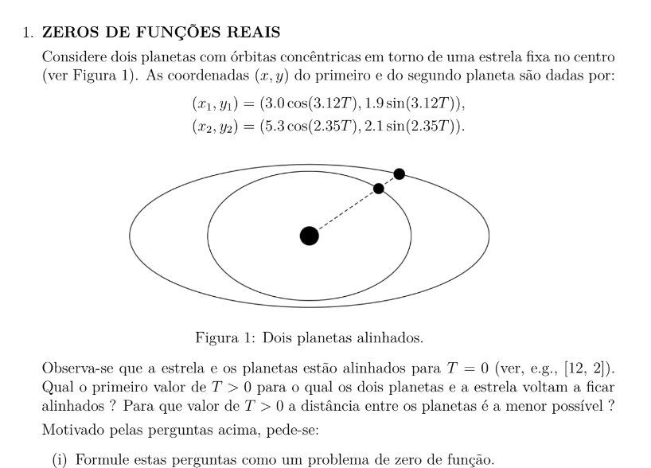

1.a) Para que os planetas estejam alinhados, deve ser possível traçar uma reta entre os 3 pontos, para isso, a seguinte matriz deve possuir determinante 0: [[x1,y1,1],[x2,y2,1], [0,0,1]], portanto, x1y2- y1x2 = 0. Logo, definimos “alinexp” como a variável que, quando igualada a zero, indica o alinhamento dos planetas. Para encontrar o instante t em que a distância entre os planetas é mínima, primeiro definimos “distexp” como a expressão da função distância e então derivamos, portanto, os zeros da função derivada devem ser mínimos ou máximos globais.

```r
#Definindo a expressão f que informa que os planetas estão alinhados quando f(x) = 0
alinexp <- expression(3*cos(3.12*t)*2.1*sin(2.35*t)-1.9*sin(3.12*t)*5.3*cos(2.35*t))

#Função que avalia uma expressão com parâmetro "t" com um número t dado.
evalfun <- function(t, exp){
  z <- eval(exp)
  return(z)
}

#Definindo a expressão que calcula a distância entre os planetas.
distexp <- expression(sqrt((3*cos(3.12*t)-5.3*cos(2.35*t))^2+(1.9*sin(3.12*t)-2.1*sin(2.35*t))^2))

#Função que deriva uma expressão de parâmetro "t" e a avalia.
derivfun <- function(t, exp){
  derivexp <- D(exp, "t")
  z <- eval(derivexp)
  return(z)
}
```

1)b) Definimos funções com os métodos da Bissecção, Falsa posição, Secante e Newton para a resolução dos problemas de zero de função definidos anteriormente.

```r
#Método da bissecção
bissec <- function(fun, ak, bk, exp = NULL){
  erro = 10^-6
  cont = 0
  xk = (ak+bk)/2
  while(erro < abs(bk - ak) | erro < abs(fun(xk, exp))){
    xk = (ak+bk)/2
    if(fun(xk, exp)*fun(ak, exp) < 0){bk = xk}
    else{ak = xk}
    cont = cont + 1
    if(cont > 10000){
      xk = 0
      break
    }
  }
  vetor <- c(xk, cont)
  return(vetor)
}

#Método da Falsa Posição
falsa_posi <- function(fun, ak, bk, exp = NULL){
  erro = 10^-6
  cont = 0
  xk = (ak*fun(bk, exp) - bk*fun(ak, exp))/(fun(bk, exp) - fun(ak, exp))
  while(erro < abs(bk - ak) | erro < abs(fun(xk, exp))){
    xk = (ak*fun(bk, exp) - bk*fun(ak, exp))/(fun(bk, exp) - fun(ak, exp))
    if(fun(xk, exp)*fun(ak, exp) < 0){bk = xk}
    else{ak = xk}
    cont = cont + 1
  }
  vetor <- c(xk, cont)
  return(vetor)
}

#Método da Secante
secante <- function(fun, x0, x1, exp = NULL){
  erro = 10^-6
  cont = 0
  while(erro < abs(x1 - x0) | erro < abs(fun(x1, exp))){
    x2 <- x1 - fun(x1, exp)*(x1 - x0)/(fun(x1, exp) - fun(x0, exp))
    x0 = x1
    x1 = x2
    cont = cont+1
  }
  vetor <- c(x2, cont)
  return(vetor)
}

#Método de Newton
newton <- function(fun, funderiv, x0, exp = NULL){
  erro = 10^-6
  cont = 0
  x1 = x0 - fun(x0, exp)/funderiv(x0, exp)
  while(erro < abs(x1 - x0) | erro < abs(fun(x1, exp))){
    x1 = x0 - fun(x0, exp)/funderiv(x0, exp)
    x0 = x1
    cont = cont + 1
  }
  vetor <- c(x0, cont)
  return(vetor)
}
```

As tabelas com cada método e o número de iterações realizado são apresentadas abaixo. A tabela 1 são os resultados da aplicação dos métodos no problema do alinhamento dos planetas, enquanto a tabela 2 mostra os resultados para o problema da distância mínima.

```r
#Cria uma tabela com o resultado de cada método aplicado ao problema de 0 de função para o alinhamento dos planetas
tabela1 <- data.frame(bissec(evalfun, 4, 4.1, alinexp), falsa_posi(evalfun, 4, 4.1, alinexp), secante(evalfun, 4, 4.1, alinexp), newton(evalfun, derivfun, 4, alinexp))

colnames(tabela1) <- c("Bissecção", "Falsa Posição", "Secante", "Newton")
rownames(tabela1) <- c("X", "Iterações")

#Cria uma tabela com o resultado de cada método aplicado ao problema de 0 de função para a distância mínima dos planetas (Usou-se f'(x) = 0 para encontrar o mínimo).
tabela2 <- data.frame(bissec(evalfun, 195.8, 195.9, D(distexp, "t")), falsa_posi(evalfun, 195.8, 195.9, D(distexp, "t")), secante(evalfun, 195.8, 195.9, D(distexp, "t")), newton(evalfun, derivfun, 195.8, D(distexp, "t")))

colnames(tabela2) <- c("Bissecção", "Falsa Posição", "Secante", "Newton")
rownames(tabela2) <- c("X", "Iterações")

#Exibe as tabelas criadas anteriormente
tabela1
```

```
##           Bissecção Falsa Posição Secante  Newton
## X           4.04299       4.04299 4.04299 4.04299
## Iterações  18.00000       7.00000 4.00000 2.00000
```

```r
tabela2
```

```
##           Bissecção Falsa Posição  Secante   Newton
## X          195.8532      195.8532 195.8532 195.8532
## Iterações   21.0000        5.0000   4.0000   4.0000
```

1)c) Na prática, a escolha dos métodos para cada problema devem levar a em consideração a facilidade de encontrar os pontos iniciais que não apresentam problemas para a resolução. Nas questões apresentadas, os pontos iniciais foram calculados analisando todas as trocas de sinais entre números de 0 a 200 com diferença de 0.1 entre si, isso se deve ao fato de que a posição dos planetas tem período 200, ou seja, t(0) = t(200) para os dois planetas, além disso, a diferença de 0.1 é pequena o suficiente para que 2.35x0.1 ≈ 0.235 e 3.12x0.1 ≈ 0.312 é inferior a π/4, o que implica que as funções cosseno e seno que apresentem uma troca de sinal entre t = x e t = x + 0.1 não apresentarão mais de uma troca de sinal nesse mesmo intervalo.

```r
#Cria uma sequência de números de 0 a 200 com passos de 0.1: 0, 0.1, 0.2, ..., 199.9, 200.
t <- seq(0, 200, 0.1)

#Função que analisa as trocas de sinais de f(a) e f(b) e as salva em uma tabela, onde a e b são números consecutivos do intervalo criado anteriormente.
intervalos <- function(fun, t, exp){
  df = data.frame(0, 0, 0, 0)
  names(df)<-c("a","b", "sgnfa", "sgnfb")
  for(n in 1:(length(t)-1)){
    if(fun(t[n], exp)*fun(t[n+1], exp) < 0){
      a = t[n]
      b = t[n+1]
      sgnfa = sign(fun(t[n], exp))
      sgnfb = sign(fun(t[n+1], exp))
      de <- data.frame(a, b, sgnfa, sgnfb)
      names(de)<-c("a","b", "sgnfa", "sgnfb")
      df <- rbind(df, de)
    }
  }
  df <- df[-1, ]
  return(df)
}

#Exibindo os intervalos criados
intervalos(evalfun, t, alinexp)
```

```
##        a     b sgnfa sgnfb
## 2    4.0   4.1    -1     1
## 3    8.0   8.1     1    -1
## 4   12.1  12.2    -1     1
## 5   16.1  16.2     1    -1
## 6   20.2  20.3    -1     1
## 7   24.2  24.3     1    -1
## 8   28.3  28.4    -1     1
## 9   32.3  32.4     1    -1
## 10  36.4  36.5    -1     1
## 11  36.8  36.9     1    -1
## 12  37.0  37.1    -1     1
## 13  40.4  40.5     1    -1
## 14  40.7  40.8    -1     1
## 15  41.0  41.1     1    -1
```

[output cut: 48 more lines]

```r
intervalos(evalfun, t, D(distexp, "t"))
```

```
##         a     b sgnfa sgnfb
## 2     0.1   0.2     1    -1
## 3     0.8   0.9    -1     1
## 4     1.6   1.7     1    -1
## 5     2.1   2.2    -1     1
## 6     2.8   2.9     1    -1
## 7     3.4   3.5    -1     1
## 8     4.0   4.1     1    -1
## 9     4.6   4.7    -1     1
## 10    5.1   5.2     1    -1
## 11    5.8   5.9    -1     1
## 12    6.3   6.4     1    -1
## 13    7.1   7.2    -1     1
## 14    7.7   7.8     1    -1
## 15    8.8   8.9    -1     1
```

[output cut: 286 more lines]

```r
#Salvando o intervalo criado para a função da distância mínima dos planetas, a fim de analisar qual dos mínimos da função é candidato a mínimo global.
dataframeint <- intervalos(evalfun, t, D(distexp, "t"))
```

O método de Newton, como só utiliza de um ponto inicial, sempre utilizou o menor dos dois pontos escolhidos para os outros métodos.

```r
#Testando os intervalos de troca de sinal encontrados anteriormente para procurar um mínimo global da função distância dos planetas a partir de uma bissecção em cada intervalo.
testeintervalo <- function(fun, t, exp, method, dataframeint){
  df = data.frame(0)
  names(df) <- "x"
  for(n in 1:(nrow(dataframeint))){
    ak = dataframeint[n,1]
    bk = dataframeint[n,2]
    x <- method(fun, ak, bk, exp)
    if(x[1] != 0){
      de <- data.frame(x[1])
      names(de) <- "x"
      df <- rbind(df, de)
    }
  }
  return(df)
}

dataframe <- testeintervalo(evalfun, t, D(distexp, "t"), bissec, dataframeint)

dataframe$f_de_x <- evalfun(dataframe$x, distexp)

#Exibe o mínimo global encontrado. Está no intervalo 195.8 e 195.9
dataframe[which.min(dataframe$f_de_x),]
```

```
##            x    f_de_x
## 295 195.8532 0.2003789
```

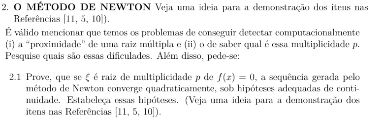

2.1) A multiplicidade p da função normalmente requere algoritmos iterativos com derivadas (tanto ou mais complicados do que o próprio método de resolução), o que dificulta seu uso [1]. A proximidade da raiz múltipla requere uma análise da função e a determinação de um intervalo inicial “seguro” para a aplicação do método de Newton, que possui características caóticas quando em condições de fronteira.

Prova em LaTeX a seguir [2]:

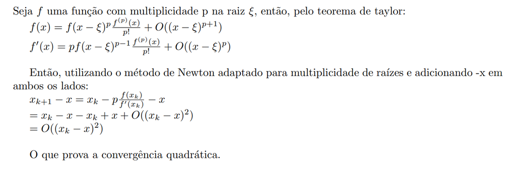

As condições de convergência quadrática, então, requerem que f’(x) seja diferente de 0 sempre (computacionalmente, é recomendado que não esteja próxima de zero também), e a função deve ser analítica, de modo a possuir expansão de Taylor em torno da raiz procurada.

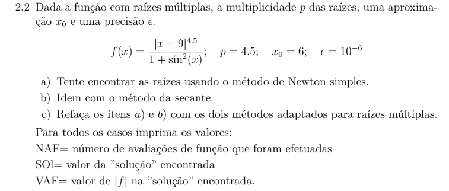

2.2 a) Definimos a função apresentada no problema, assim como sua derivada, como as funções “funcproblema22” e “derivfuncproblema22” respectivamente. Após isso, aplicamos o método de Newton simples (p = 1) para a resolução do problema.

```r
#Define a função apresentada no problema
funcproblema22 <- function(x){
  valor <- (abs(x-9)^4.5)/(1+(sin(x))^2)
  return(valor)
}
#Define a derivada da solução apresentada no problema
derivfuncproblema22 <- function(x){
  valor <- (4.5*(x-9)*abs(x-9)^2.5)/(1+sin(x)^2) - (2*abs(x-9)^4.5*sin(x)*cos(x))/(1+sin(x)^2)^2
  return(valor)
}
#Método de Newton, quando o parâmetro p = 1, tem-se o método de Newton Simples.
newtonproblema22 <- function(f, df, x0, p){
  cont = 0
  erro = 10^-6
  x1 = x0 - p*f(x0)/df(x0)
  while(abs(x1 - x0) > erro | abs(f(x1)) > erro){
    x0 = x1
    x1 = x0 - p*f(x0)/df(x0)
    cont = cont + 1
  }
  NAF = cont
  SOL = x1
  VAL = f(x1)
  vetor <- c(NAF, SOL, VAL)
  names(vetor) <- c("NAF", "SOL", "VAL")
  vetor <- format(vetor, scientific = FALSE)
  return(vetor)
}


#Imprime o método de Newton Simples aplicado ao problema do enunciado
newtonproblema22(funcproblema22, derivfuncproblema22, 6, 1)
```

```
##                                  NAF                                  SOL
## "53.0000000000000000000000000000000" " 8.9999967518024686086164365406148"
##                                  VAL
## " 0.0000000000000000000000001714995"
```

2. Aplicamos o método da secante simples (p = 1) para a resolução do problema. Com o método da secante precisa de 2 pontos iniciais para funcionar, definimos o primeiro ponto inicial pelo que foi dado pela questão, x0 = 6, e o segundo ponto inicial é o ponto da segunda iteração dado pelo método de Newton simples.

```r
#Método da Secante, quando p = 1, tem-se o método da secante simples.
secante1ponto <- function(f, df, x0, p){
  cont = 0
  erro = 10^-6
  x1 = x0 - f(x0)/df(x0)
  x2 = x1 - (p*f(x1)*(x1-x0))/(f(x1)-f(x0))

  while(abs(x2 - x1) > erro | abs(f(x2)) > erro){
    x0 = x1
    x1 = x2
    x2 = x1 - (p*f(x1)*(x1-x0))/(f(x1)-f(x0))
    cont = cont + 1
  }
  NAF = cont
  SOL = x2
  VAL = f(x2)
  vetor <- c(NAF, SOL, VAL)
  names(vetor) <- c("NAF", "SOL", "VAL")
  vetor <- format(vetor, scientific = FALSE)
  return(vetor)
}

#Imprime o método da secante aplicado ao problema do enunciado.
secante1ponto(funcproblema22, derivfuncproblema22, 6, 1)
```

```
##                                 NAF                                 SOL
## "73.000000000000000000000000000000" " 8.999994758401365757549683621619"
##                                 VAL
## " 0.000000000000000000000001477265"
```

3. Com as funções anteriores, utilizamos os métodos de Newton e da Secante adaptados para a multiplicidade apresentada (p = 4.5).

```r
#Apresenta os resultados do método de Newton adaptado.
newtonproblema22(funcproblema22, derivfuncproblema22, 6, 4.5)
```

```
## NAF SOL VAL
## "5" "9" "0"
```

```r
#Apresenta os resultados do método da Secante adaptado.
secante1ponto(funcproblema22, derivfuncproblema22, 6, 4.5)
```

```
##                            NAF                            SOL
## "11.0000000000000000000000000" " 8.9999302265153939828223884"
##                            VAL
## " 0.0000000000000000001692234"
```

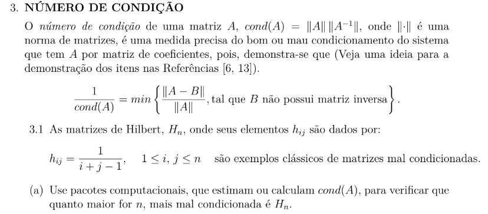

3.1 a) Os pacotes utilizados são PRACMA e MATRIXCALC, que se especializam em funções e operações com Matrizes. São usadas as funções que criam matrizes de hilbert n por n, assim como o condicionamento dado pela norma 2, os resultados são então apresentados em uma tabela.

```r
#Pacotes para cálculos com matrizes.
library(pracma)
library(matrixcalc)

#Cria uma tabela com o tamanho da matriz de Hilbert e seu respectivo condicionamento.
f <- data.frame(Tamanho_Matriz_Hilbert= 2:12)
n = 2
while(n < nrow(f)+2){
  #Matriz de Hilbert nxn
  matrix <- hilbert.matrix(n)
  #Condicionamento com norma p = 2
  f$Condicionamento[n-1] <- cond(matrix)
  n = n + 1
}

#Exibe a tabela
f
```

```
##    Tamanho_Matriz_Hilbert Condicionamento
## 1                       2    1.928147e+01
## 2                       3    5.240568e+02
## 3                       4    1.551374e+04
## 4                       5    4.766073e+05
## 5                       6    1.495106e+07
## 6                       7    4.753674e+08
## 7                       8    1.525758e+10
## 8                       9    4.931545e+11
## 9                      10    1.602529e+13
## 10                     11    5.225191e+14
## 11                     12    1.802561e+16
```

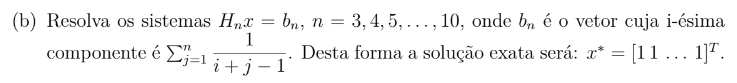

3.1 b) Definimos uma função que cria a matriz de hilbert Hn n por n e o vetor Bn a partir da soma das linhas da respectiva matriz, após isso, a função Solve() do R resolve o sistema de equações Hn*X = Bn e imprime a resposta. Essa função então é aplicada para os valores de n entre 3 e 10.  
A função Solve() da base do R usa de mecanismos do código do LAPACK para resolver equações e sistemas de equação, isso é feito a partir da seguinte forma: primeiro computa-se a fatorização LU (Lower-Upper) usando pivoteamento parcial e troca de linhas, depois o sistema é resolvido usando substituição.

```r
#Função para resolver os sistemas de equação propostos.
sistemas <- function(n){
  hn <- hilbert.matrix(n)
  vetor <- rowSums(hn)
  x <- solve(hn, vetor)
  print(x)
}

for(k in 3:10){
  sistemas(k)
}
```

```
## [1] 1 1 1
## [1] 1 1 1 1
## [1] 1 1 1 1 1
## [1] 1 1 1 1 1 1
## [1] 1 1 1 1 1 1 1
## [1] 1.0000000 1.0000000 1.0000000 1.0000000 1.0000001 0.9999999 1.0000001
## [8] 1.0000000
## [1] 1.0000000 1.0000000 1.0000000 1.0000002 0.9999994 1.0000012 0.9999988
## [8] 1.0000007 0.9999998
##  [1] 1.0000000 0.9999998 1.0000037 0.9999666 1.0001582 0.9995672 1.0007071
##  [8] 0.9993190 1.0003564 0.9999218
```

```r
sistemas(11) #por curiosidade
```

```
##  [1] 1.0000000 1.0000002 0.9999941 1.0000676 0.9995917 1.0014507 0.9968148
##  [8] 1.0043723 0.9963474 1.0016981 0.9996632
```

```r
#sistemas(12) causa erro - Error in solve.default(hn, vetor) : system is computationally singular: reciprocal condition number = 2.63277e-17
```

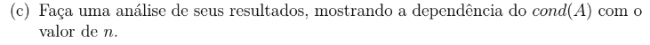

3.1 c) Analisando o número de condicionamento da Matriz de Hilbert pelo seu tamanho, podemos notar um aumento que sugere um crescimento exponencial conforme n cresce. Com isso, é possível fazer uma análise de regressão da seguinte forma: Seja Y = Log(Condicionamento) e X = Tamanho da Matriz de Hilbert, utilizando as funções lm e summary do R para produzir e apresentar dados da análise de regressão de Y ~ X, podemos notar a estatística R² = 0.9999 indicando um ajuste linear quase perfeito, o que reforça a ideia do crescimento exponencial do número de condicionamento. Então, podemos construir o gráfico do logaritmo natural do condicionamento pelo tamanho da matriz e então traçar a reta de regressão encontrada pelo método dos mínimos quadrados definido na função lm(), que se ajusta naturalmente aos pontos. Por fim, imprimimos os erros entre os resultados obtidos e o valor esperado pela reta de regressão, é notável que o módulo dos erros é menor do que 1 (Um erro relativo baixíssimo), porém o gráfico sugere heterocedasticidade dos dados.

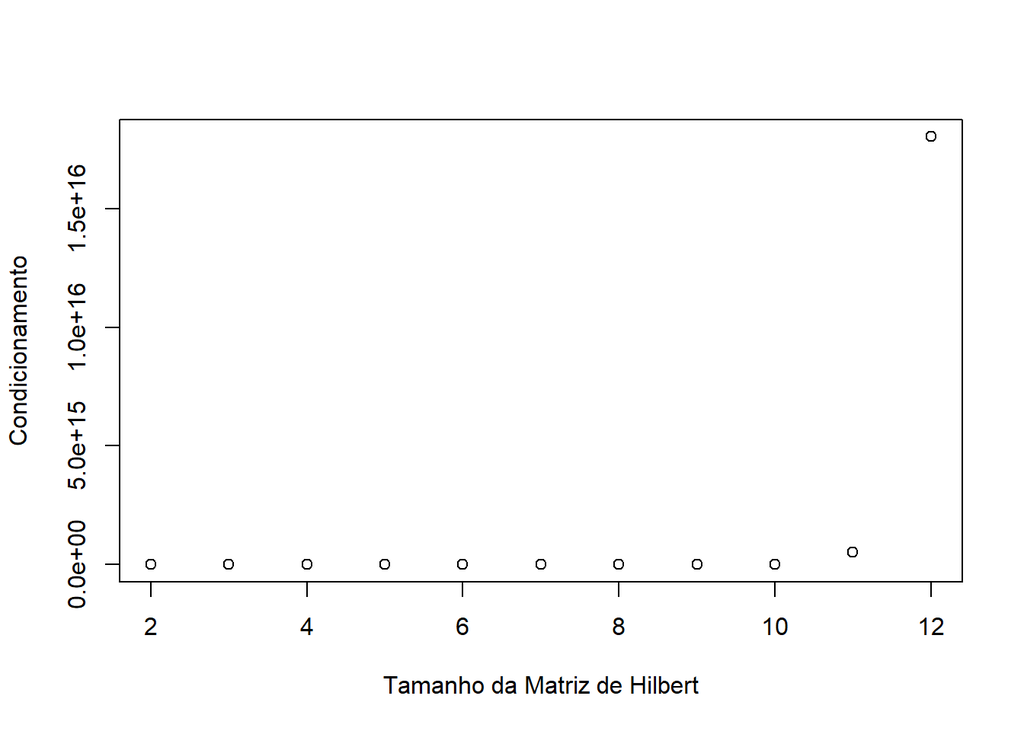

```r
#Gráficos que apresentam relação positiva entre o tamanho da matriz de Hilbert e seu condicionamento

plot(f, xlab = "Tamanho da Matriz de Hilbert", ylab = "Condicionamento")
```

```r
analise <- data.frame(Tamanho_Matriz_Hilbert= 2:12)
n = 2
while(n < nrow(analise)+2){
  matrix <- hilbert.matrix(n)
  analise$Condicionamento[n-1] <- cond(matrix)
  n = n + 1
}

#Retorna as estatísticas da análise de regressão linear do logaritmo natural do condicionamento pelo tamanho da matriz de Hilbert.
summary(lm(log(Condicionamento) ~ Tamanho_Matriz_Hilbert, data = analise))
```

```
##
## Call:
## lm(formula = log(Condicionamento) ~ Tamanho_Matriz_Hilbert, data = analise)
##
## Residuals:
##      Min       1Q   Median       3Q      Max
## -0.07662 -0.06154 -0.03002  0.02633  0.17183
##
## Coefficients:
##                         Estimate Std. Error t value Pr(>|t|)
## (Intercept)            -4.117482   0.062898  -65.46 2.29e-13 ***
## Tamanho_Matriz_Hilbert  3.452399   0.008189  421.61  < 2e-16 ***
## ---
## Signif. codes:  0 '***' 0.001 '**' 0.01 '*' 0.05 '.' 0.1 ' ' 1
##
## Residual standard error: 0.08588 on 9 degrees of freedom
## Multiple R-squared:  0.9999, Adjusted R-squared:  0.9999
## F-statistic: 1.778e+05 on 1 and 9 DF,  p-value: < 2.2e-16
```

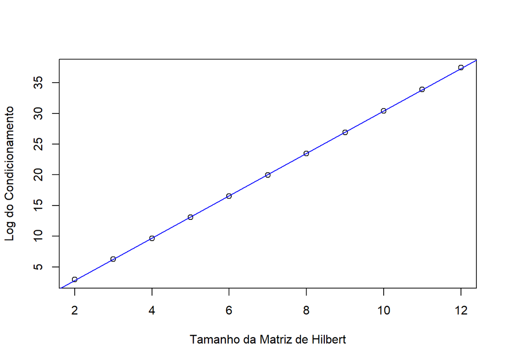

```r
#Imprime o gráfico do Log do Condicionamento pelo tamanho da matriz, juntamente com a reta que minimiza o erro quadrático médio dos pontos.
plot(analise$Tamanho_Matriz_Hilbert, log(analise$Condicionamento), xlab = "Tamanho da Matriz de Hilbert", ylab = "Log do Condicionamento")
abline(lm(log(Condicionamento) ~ Tamanho_Matriz_Hilbert, data = analise), col = "blue")
```

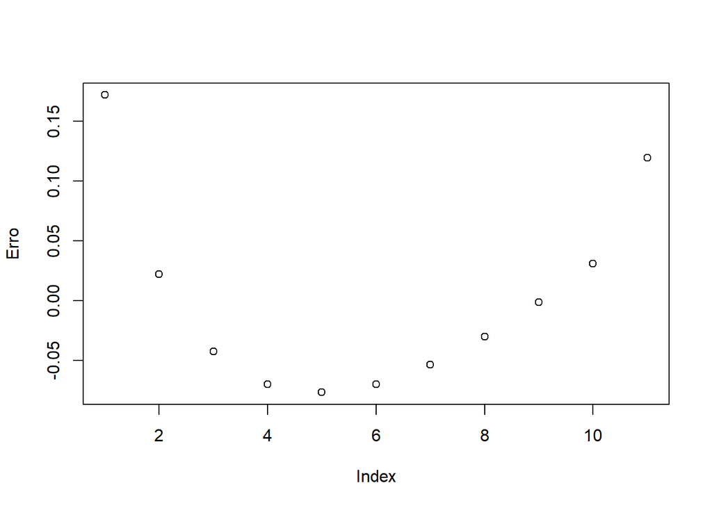

[figure not shown]

```r
#Imprime o valor do erro de cada ponto comparado a sua estimativa pela reta de regressão.
plot(log(analise$Condicionamento) - fitted.values(lm(log(Condicionamento) ~ Tamanho_Matriz_Hilbert, data = analise)), ylab = "Erro")
```

4)a) Resolução escrita em LaTeX:

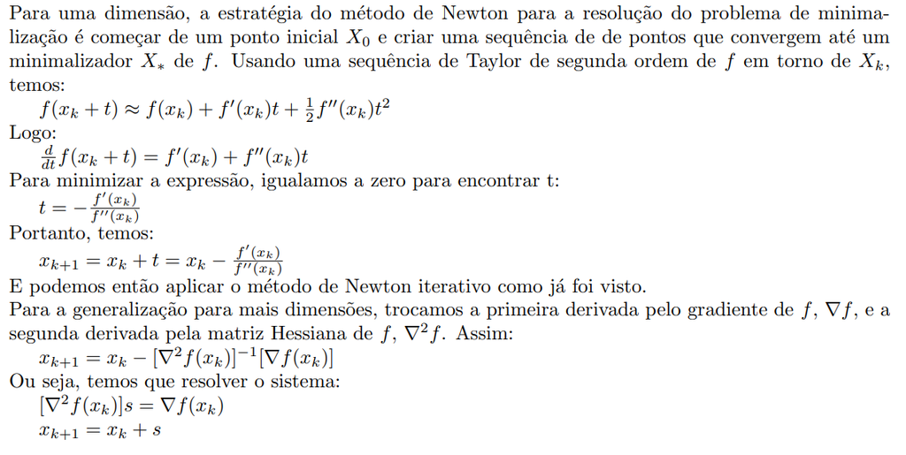

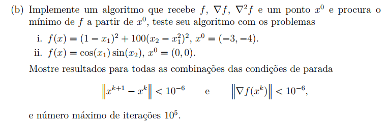

4. b) As funções a seguir avaliam a expressão dada, retornam seu gradiente, sua hessiana e computam o método iterativo de Newton descrito no item anterior, respectivamente.

```r
#Função que avalia a expressão f(x,y) em x e y dados.
f <- function(exp, x, y){
  final <- eval(exp)
  return(final)
}

#Função que cria e avalia o gradiente de f(x,y) em x e y dados.
gradf <- function(exp, x, y){
  dxexp <- D(exp, "x")
  dyexp <- D(exp, "y")
  final <- c(eval(dxexp), eval(dyexp))
  return(final)
}

#Função que cria e avalia a matriz de f(x,y) em x e y dados.
hesf <- function(exp, x, y){
  dxx <- D(D(exp, "x"), "x")
  dxy <- D(D(exp, "x"), "y")
  dyx <- D(D(exp, "y"), "x")
  dyy <- D(D(exp, "y"), "y")
  final <- matrix(c(eval(dxx), eval(dxy), eval(dyx), eval(dyy)), nrow = 2, ncol = 2)
  return(final)
}

#A função recebe o ponto inicial, a expressão original, assim como seu gradiente e hessiana, e resolve o sistema de equações Hess * X = -Grad iterativamente se aproximando do ponto (x,y) que zera a equação inicial. Com o argumento cond_parada é possível escolher a condição de parada da função de acordo com as combinações especificadas na questão.
newtonmult <- function(f, gradf, hesf, exp, x, y, e1, e2, k, p, cond_parada){
  aux = 0
  x0 <- as.matrix(c(x, y))
  xk <- x0

  if(cond_parada == 1){
    while(norm(as.matrix(gradf(exp, x, y)), as.character(p)) >= e1 & aux < k){
      s = solve(hesf(exp, x, y), -gradf(exp, x, y))
      x = s[1] + x
      y = s[2] + y
      aux = aux + 1
    }
    vetor <- c(x, y, aux, f(exp, x, y))
    vetor <- format(vetor, scientific = FALSE)
    return(vetor)
  }
  if(cond_parada == 2){
    erro = 1
    while(erro >= e2 & aux < k){
      s = solve(hesf(exp, x, y), -gradf(exp, x, y))
      xwhole = as.matrix(c(x, y))
      xk = s + xwhole
      erro = norm(xk - xwhole)
      x = s[1] + x
      y = s[2] + y
      aux = aux +1
    }
    vetor <- c(x, y, aux, f(exp, x, y))
    vetor <- format(vetor, scientific = FALSE)
    return(vetor)
  }
  if(cond_parada == 6){
    while(aux < k){
      s = solve(hesf(exp, x, y), -gradf(exp, x, y))
      x = s[1] + x
      y = s[2] + y
      aux = aux + 1
    }
    vetor <- c(x, y, aux, f(exp, x, y))
    vetor <- format(vetor, scientific = FALSE)
    return(vetor)
  }
  if(cond_parada == 3){
    while(norm(as.matrix(gradf(exp, x, y)), as.character(p)) >= e1){
      s = solve(hesf(exp, x, y), -gradf(exp, x, y))
      x = s[1] + x
      y = s[2] + y
      aux = aux +1
    }
    vetor <- c(x, y, aux, f(exp, x, y))
    vetor <- format(vetor, scientific = FALSE)
    return(vetor)
  }
  if(cond_parada == 4){
    erro = 1
    while(erro >= e2){
      s = solve(hesf(exp, x, y), -gradf(exp, x, y))
      xwhole = as.matrix(c(x, y))
      xk = s + xwhole
      erro = norm(xk - xwhole)
      x = s[1] + x
      y = s[2] + y
      aux = aux +1
    }
    vetor <- c(x, y, aux, f(exp, x, y))
    vetor <- format(vetor, scientific = FALSE)
    return(vetor)
  }
  if(cond_parada == 5){
    erro = 1
    while(erro >= e2 & aux < k & norm(as.matrix(gradf(exp, x, y)), as.character(p)) >= e1){
      s = solve(hesf(exp, x, y), -gradf(exp, x, y))
      xwhole = as.matrix(c(x, y))
      xk = s + xwhole
      erro = norm(xk - xwhole)
      x = s[1] + x
      y = s[2] + y
      aux = aux +1
    }
    vetor <- c(x, y, aux, f(exp, x, y))
    vetor <- format(vetor, scientific = FALSE)
    return(vetor)
  }
}
```

A segunda função, utilizando cosseno e seno, não pode ser computada a partir do ponto (0,0) pois isso resulta em uma matriz hessiana singular em sua primeira iteração, impossibilitando o uso da sua inversa, e portanto, impossibilitando a resolução do sistema de equações

```r
#Define as expressões dadas na questão
exp42 <- expression(cos(x)*sin(y))

exp41 <- expression((1-x)^2 + 100*(y - x^2)^2)

dfnewtonmult <- data.frame(0,0,0,0,0)

#Aplica a função em cada uma das expressões, para cada método de parada possível, e salva os resultados em uma tabela
for(j in 1:5){
  l1 <- newtonmult(f, gradf, hesf, exp41, -3, -4, 10^-6, 10^-6, 10^5, 2, j)
  #l2 <- newtonmult(f, gradf, hesf, exp42, 0, 0, 10^-6, 10^-6, 10^5, 2, j) Causa erro Error in solve.default(hesf(exp, x, y), -gradf(exp, x,
  #Arredonda os resultados para as primeiras 10 casas decimais
  l1[1] <- round(as.numeric(l1[1]), 10)
  l1[2] <- round(as.numeric(l1[2]), 10)
  l1[3] <- round(as.numeric(l1[3]), 10)
  l1[4] <- round(as.numeric(l1[4]), 10)
  dfnewtonmult <- rbind(dfnewtonmult, c(j,l1))
  #dfnewtonmult <- rbind(dfnewtonmult, c(j,l2))
}

colnames(dfnewtonmult) <- c("Condição de Parada","X", "Y", "Iterações", "F(x,y)")

#Imprime a tabela com todos os valores do vetor (x,y), iterações, condição de parada, entre outros.
dfnewtonmult[-1,]
```

```
##   Condição de Parada X Y Iterações F(x,y)
## 2                  1 1 1         5      0
## 3                  2 1 1         6      0
## 4                  3 1 1         5      0
## 5                  4 1 1         6      0
## 6                  5 1 1         5      0
```

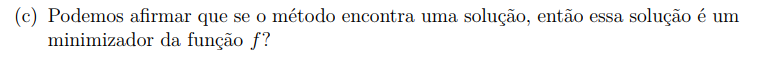

4.c) Não necessariamente, o método encontra pontos críticos locais da função, que podem ser apenas mínimos locais ou até mesmo pontos de máximo

Referências:

[1] Dixon, John. (2009). Suspension Geometry and Computation. Suspension Geometry and Computation. 1-417.

[2] Wang, Jimmy. https://math.stackexchange.com/questions/93156/newtons-method-for-roots-of-multiplicity-1. Acesso: 28/09/2022

[3] C. D. Meyer, Matrix analysis and applied linear algebra, SIAM, 2000

[4] M. A. Gomes Ruggiero, V. L. da Rocha Lopes. Cálculo Numérico - Aspectos Teóricos e Computacionais, 2ª edição, Editora Pearson, 1997. · M.C. Cunha.